We can also “visualize” the segments using **snake plots** for each cluster. For example, we can plot the means of the profiling variables for each of our clusters to better visualize differences between segments. For better visualization we plot the standardized profiling variables.

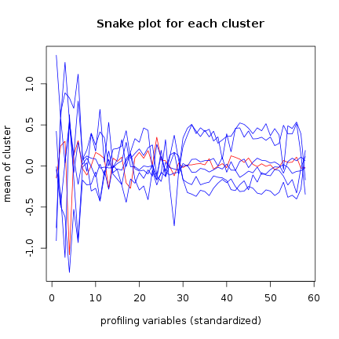

We can also compare the averages of the profiling variables of each segment relative to the average of the variables across the whole population. This can also help us better understand whether there are indeed clusters in our data (e.g. if all segments are much like the overall population, there may be no segments). For example, we can measure the ratios of the average for each cluster to the average of the population (e.g. avg(cluster)/avg(population)) and explore a matrix as the following one:

|  | Segment 1 | Segment 2 | Segment 3 | Segment 4 | Segment 5 | Segment 6 | Segment 7 |
| --- | --- | --- | --- | --- | --- | --- | --- |
| Q1_2_When.buying.a.boat..getting.the.lowest.price.is.more.important.than.the.boat.brand | 0.9483 | 0.7348 | 0.6796 | 1.149 | 1.474 | 0.9857 | 0.9976 |
| Q1_4_I.only.consider.buying.a.boat.from.a.reputable.brand | 1.052 | 1.122 | 1.137 | 0.8986 | 1.123 | 0.8964 | 0.9258 |
| Q1_9_I.see.my.boat.as.a.status.symbol | 1.112 | 1.013 | 1.332 | 1.017 | 1.471 | 0.7691 | 0.5837 |
| Q1_11_I.tend.to.perform.minor.boat.repairs.and.maintenance.on.my.own | 0.6397 | 1.166 | 1.276 | 1.18 | 1.186 | 0.568 | 1.209 |
| Q1_21_Boating.helps.me.escape.from.everyday.life.and.relax | 1.023 | 1.017 | 1.12 | 0.986 | 1.022 | 0.9101 | 0.9739 |
| Q1_27_Boating.is.the.number.one.thing.I.do.with.my.spare.time | 1.103 | 0.9253 | 1.372 | 1.097 | 1.263 | 0.689 | 0.7039 |
| Q2_How.many.powerboats.do.you.currently.own. | 0.9712 | 1.067 | 1.072 | 1.016 | 1.114 | 0.8502 | 0.988 |
| Q2_Cluster_Own.a.boat. | 0.9347 | 1.071 | 1.114 | 1.057 | 0.9609 | 0.864 | 1.023 |
| Q3_How.likely.would.you.be.to.purchase.a.new.boat.in.the.future. | 1.001 | 1.016 | 1.068 | 0.9987 | 1.067 | 0.9628 | 0.9484 |
| Q4_Approximately.how.much.did.you.pay.for.your.current.Boat. | 1.097 | 1.051 | 1.151 | 0.9221 | 1.105 | 0.958 | 0.8403 |
| Q5_What.is.the.horse.power.of.your.engine.brand.current.boat.engine…the.boat.you.want.to.buy. | 1.064 | 0.9875 | 1.198 | 1.011 | 1.328 | 0.80 | 0.7958 |
| Q6_Length.of.Boat..in.Feet. | 1.043 | 0.9938 | 1.161 | 0.9473 | 1.021 | 0.9759 | 0.9446 |
| Q7_1_I.normally.boat.alone | 0.8632 | 0.9882 | 0.9995 | 1.092 | 1.266 | 0.8579 | 1.04 |
| Q7_2_I.boat.with.my.spouse.or.significant.other | 1.027 | 0.994 | 1.057 | 0.9777 | 0.9938 | 1.001 | 0.9724 |
| Q7_3_I.boat.with.my.family..including.kids | 1.017 | 1.009 | 1.063 | 0.9892 | 1.025 | 0.9847 | 0.9515 |
| Q7_4_I.boat.with.my.friends | 1.026 | 1.015 | 1.058 | 0.9877 | 1.077 | 0.9437 | 0.9462 |
| Q8_How.would.you.rate.your.experience.regarding.boating. | 0.9283 | 1.10 | 1.15 | 1.032 | 0.9967 | 0.846 | 1.021 |
| Q9_1_Fishing…Below.is.a.list.of.activities.that.may.or.may.not.do.while.boating..Please.indicate.how.often.you.engage.in.each.of.these.activities | 0.9051 | 0.9972 | 1.032 | 1.053 | 1.06 | 0.9452 | 1.051 |
| Q9_2_Swimming…Below.is.a.list.of.activities.that.may.or.may.not.do.while.boating..Please.indicate.how.often.you.engage.in.each.of.these.activities | 1.031 | 0.9969 | 1.048 | 0.9898 | 1.104 | 0.9346 | 0.949 |
| Q9_3_Cruising…Below.is.a.list.of.activities.that.may.or.may.not.do.while.boating..Please.indicate.how.often.you.engage.in.each.of.these.activities | 1.043 | 0.9878 | 1.054 | 0.984 | 1.075 | 0.9796 | 0.9242 |
| Q9_4_Water.Sports…Below.is.a.list.of.activities.that.may.or.may.not.do.while.boating..Please.indicate.how.often.you.engage.in.each.of.these.activities | 1.034 | 1.00 | 1.047 | 0.9816 | 1.17 | 0.9446 | 0.9113 |
| Q9_5_Entertaining.socializing…Below.is.a.list.of.activities.that.may.or.may.not.do.while.boating..Please.indicate.how.often.you.engage.in.each.of.these.activities | 1.056 | 0.9972 | 1.066 | 0.9708 | 1.13 | 0.986 | 0.8769 |
| Q10_During.your.boating.season..how.many.days.out.of.the.year.do.you.typically.use.your.boat | 1.014 | 1.004 | 1.245 | 1.016 | 0.9506 | 0.8807 | 0.9494 |
| Q11_Gender | 1.121 | 0.9426 | 0.9626 | 0.9572 | 0.9411 | 1.091 | 0.9202 |
| Q12_HOUSEHOLD.income | 1.025 | 1.067 | 1.039 | 0.9348 | 0.9672 | 1.035 | 0.9738 |
| Q13_Are.you.now.married..widowed..divorced..separated..never.married..or.living.with.a.partner. | 1.055 | 0.8845 | 0.9384 | 1.038 | 1.277 | 0.9462 | 0.8933 |
| Q14_Current.Employment.Status | 0.9922 | 1.016 | 0.9067 | 0.9832 | 0.7752 | 1.112 | 1.097 |
| Q15_Age.in.cluster | 0.9457 | 1.075 | 0.9614 | 0.9834 | 0.6703 | 1.075 | 1.169 |
| Q16_Name.of.the.Brand.rated | 1.031 | 0.9191 | 0.9373 | 0.9586 | 0.944 | 1.101 | 1.059 |
| Q16_1_Is.a.brand.that.has.been.around.for.a.long.time | 0.9946 | 1.009 | 1.066 | 0.9999 | 1.096 | 0.9539 | 0.9533 |
| Q16_2_Has.best.in.class.customer.service | 1.003 | 0.9992 | 1.091 | 1.002 | 1.111 | 0.9218 | 0.9507 |
| Q16_3_Has.a.strong.dealer.network | 1.003 | 1.017 | 1.107 | 0.9837 | 1.109 | 0.9267 | 0.9515 |
| Q16_4_Is.a.leader.in.cutting.edge.technology | 1.005 | 1.018 | 1.09 | 0.9844 | 1.083 | 0.9217 | 0.9732 |
| Q16_5_Is.a.leader.in.safety | 1.006 | 1.011 | 1.078 | 0.9937 | 1.101 | 0.9356 | 0.9501 |
| Q16_6_Is.known.for.its.innovative.products | 1.003 | 1.014 | 1.092 | 0.9913 | 1.089 | 0.9343 | 0.9557 |
| Q16_7_Is.a.brand.for.people.who.are.serious.about.boating | 1.018 | 1.014 | 1.073 | 0.9849 | 1.092 | 0.9255 | 0.9594 |
| Q16_8_Is.a.good.brand.for.people.that.are.new.to.boating | 0.9926 | 1.018 | 1.084 | 0.9908 | 1.06 | 0.9465 | 0.9761 |
| Q16_9_Is.a.brand.I.see.in.the.water.all.the.time | 0.9994 | 1.00 | 1.056 | 0.9969 | 1.071 | 0.9579 | 0.9724 |
| Q16_10_Offers.boats.that.provide.a.fast.and.powerful.boating.experience | 1.006 | 1.023 | 1.069 | 0.9919 | 1.018 | 0.9643 | 0.9684 |
| Q16_11_Offers.the.best.boats.for.socializing | 0.9947 | 0.9807 | 1.091 | 1.006 | 1.099 | 0.9488 | 0.9557 |
| Q16_12_Offers.the.best.boats.for.water.sports..e.g…tubing..ski..wakeboard. | 1.031 | 1.013 | 1.091 | 0.9874 | 1.043 | 0.9605 | 0.9275 |
| Q16_13_Offers.boats.with.superior.interior.style | 1.025 | 0.9869 | 1.106 | 0.9877 | 1.108 | 0.9409 | 0.9298 |
| Q16_14_Offers.boats.with.superior.exterior.style | 1.018 | 1.012 | 1.116 | 0.9694 | 1.102 | 0.9313 | 0.9496 |
| Q16_15_Offers.boats.that.stand.out.from.the.crowd | 1.009 | 1.017 | 1.103 | 0.9789 | 1.071 | 0.938 | 0.9634 |
| Q16_16_Offers.boats.that.look.cool | 1.024 | 0.9951 | 1.112 | 0.9849 | 1.104 | 0.9395 | 0.9292 |
| Q16_17_Offers.boats.that.can.handle.rough.weather.or.choppy.water | 1.004 | 1.01 | 1.081 | 0.9829 | 1.068 | 0.9443 | 0.9777 |
| Q16_18_Offers.boats.that.can.handle.frequent.and.heavy.usage | 0.9985 | 1.019 | 1.092 | 0.9975 | 1.066 | 0.9344 | 0.9611 |
| Q16_19_Offers.a.wide.breadth.of.product.offerings.and.accessories | 1.005 | 1.013 | 1.083 | 0.9805 | 1.068 | 0.9337 | 0.9843 |
| Q16_20_Offers.boats.that.I.can.move.around.safely | 0.9992 | 1.011 | 1.092 | 0.9827 | 1.056 | 0.948 | 0.9804 |
| Q16_21_Offers.boats.that.are.easy.to.maintain.and.or.repair | 1.003 | 1.007 | 1.07 | 0.9916 | 1.067 | 0.942 | 0.9773 |
| Q16_22_Offers.boats.that.are.easy.to.use | 0.9917 | 1.009 | 1.083 | 0.9981 | 1.045 | 0.934 | 0.9923 |
| Q16_23_Offers.boats.that.are.easy.to.clean.up | 0.9973 | 1.003 | 1.066 | 0.9975 | 1.048 | 0.9434 | 0.9904 |
| Q16_24_Has.low.prices | 1.019 | 0.9754 | 0.9876 | 1.005 | 1.139 | 0.9451 | 0.9654 |
| Q16_25_Is.a.brand.that.gives.me.peace.of.mind | 1.01 | 1.013 | 1.117 | 0.9964 | 1.094 | 0.9087 | 0.9444 |
| Q16_26_Makes.me.feel.I.made.a.smart.decision | 1.009 | 1.018 | 1.088 | 0.9824 | 1.076 | 0.9312 | 0.9681 |
| Q16_27_Is.a.brand.that.impresses.others | 1.025 | 1.015 | 1.125 | 0.9847 | 1.12 | 0.9061 | 0.9231 |
| Q17_Recommend | 0.9618 | 1.154 | 1.551 | 0.9177 | 1.202 | 0.6057 | 0.9687 |
| Q18_PurchaseFuture | 0.9846 | 1.065 | 0.8267 | 0.9787 | 0.6514 | 1.193 | 1.118 |

#### Step 8. Assess the robustness of our clusters

For the class, we will skip this step. However in practice this is a very important step.